# Configure experiments with dexR

Sascha Holzhauer

2019-05-16

# 1 Setup and run sample project

To create a sample project, execute:

```r
demo(config, package="dexR", echo=F)
```

To run the smaple project, call:

```r
demo(run, package="dexR", echo=F)
```

NOTE: The demo files reside in the R session’s temporary folder and will be removed after closing R.

# 2 Setup

## 2.1 Setup environment

As explained in Intro, configuration of dexR is done on four levels (project > machine > project version > simulation). Files for the first two levels need to be copied to project-specifc location once for a project:

```r
dexpa <- dexR::param_getDefaultDexpa()
dexpa$dirs$project <- "/home/USER/dexr/project"
dexpa$dirs$config <- "/home/USER/dexr/project/config"
dexR::setup_environment(dexpa)
```

No it’s time to adapt `dexpa-project.R` and `dexpa-machine_machine.R` to your needs.

## 2.2 Setup a new project version

For a given project version, dexR reads pointers to specific CSV config files from `DEX_Param_Configs.ods` (or alternatively `DEX_Param_Configs.csv`) and a run information is stored in `DEX_Runs.csv`. These two file and the version-specifc configuration file are copied to the specified locations by calling the following code:

```r
source("/home/USER/dexr/scripts/dexpa-machine_machine.R")
dexpa$sim$version <- "TestA
dexR::setup_project_version(dexpa)
```

You can now adapt `<project>/scripts/<version>/dexpa-pversion_<version>.R`

# 3 Configuration

After setting up the environment one needs to configure the simulation by following the course of configuration, which is explained in more detail during the next sections. The EMG uses XML configurations to initialise resources. To facilitate the creation of XML of many entities, configurations can be defined in CSV tables, which are then tranfered to XML by using the Java tool `EmgConfigTool`.

## 3.1 Principle course of configuration

1. Copy CSV templates
2. Edit CSV tables (manual!)
3. Market-Backend Warm-up/initialisation
4. Configure market products and clients in DB
5. Generate EMG XML configuration

## 3.2 Copy CSV templates

Adapt and exute the following to copy CSV templates to the specified location:

```r
source("/home/USER/dexr/scripts/dexpa-machine_machine.R")
dexpa$sim$version <- "TestA"
dexpa$sim$id      <- "Testrun01"

dexR::hl_config_copycsvtemplates(dexpa)
```

Then, add the configuration to dedicated CSV files. These tables should be considered:

- DevicesBuilding
- DevicesPVplant
- DecvicesStorage
- DevicesWindplant
- EnaviClient
- Generations
- LoadProfiles
- Loads
- OgemaConfig
- RequestConfig

The CSV file for `MarketProducts` ist required for teh configuration of the market server.

The version-specific file `DEX_Param_Configs.ods` defines for each simulation ID the CSV tables to apply as sources for the XML configuration.

The following figure shows which table information goes to which EMG XML configuration, and a suggested order of editing the CSV files:

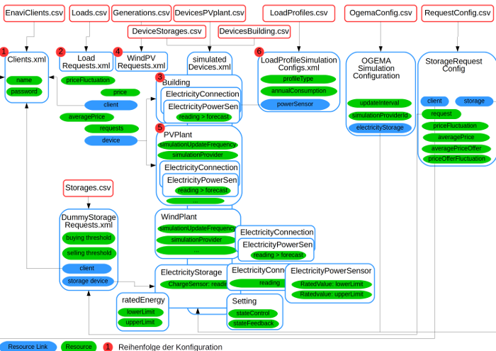

# 4 Configuration within dexR

## 4.1 Default Configuration

The file (./dexr_params.R` contains all defined dexr parameters and its defaults:

```r
################################################################
# General SIMulation Properties:
################################################################

if (!exists("dexpa")) dexpa <- list()
dexpa$sim <- list()

dexpa$sim$version           <- "version"
dexpa$sim$id                <- c("NN")
dexpa$sim$duration          <- 2*60*60             # in sec
dexpa$sim$timefactor            <- 60.0

dexpa$sim$firstdeliverystart        <- list()
dexpa$sim$firstdeliverystart$delay  <- 0

dexpa$sim$starttime_min     <- as.numeric(strptime("01/01/1970 00:00", "%d/%m/%Y %H:%M"))*1000
dexpa$sim$starttime_max     <- as.numeric(strptime("31/12/2099 24:00", "%d/%m/%Y %H:%M"))*1000

dexpa$sim$filter$requests       <- function(dexpa, data) {
                        dplyr::filter(data, TRUE)
                       }

dexpa$sim$filter$clearings      <- function(dexpa, data) {
                        dplyr::filter(data, TRUE)
                       }
### Basic ################################################################
dexpa$remoteserver          <- FALSE

### Directories ################################################################

dexpa$dirs <- list()
dexpa$dirs$project          <- "./"
dexpa$dirs$config           <- "./config"

dexpa$dirs$freemarkertemplate   <- system.file("config/freemarker", package="dexR")
dexpa$dirs$csvtemplates     <- system.file("config/csv", package="dexR")
dexpa$dirs$xmltemplatesstatic   <- system.file("config/xml_static", package="dexR")

# If empty, the a path relativ to dexpa$dirs$emgconfigtool is used!
dexpa$dirs$emgrundir            <- NULL
dexpa$dirs$emgnoderundir        <- "/local/ogema-run-dir"
dexpa$dirs$emglogdir            <- "data/logs"

dexpa$dirs$output <- list()
dexpa$dirs$outputdir            <- paste(dexpa$dirs$project, "output/version/", sep="")
dexpa$dirs$output$rdata     <- paste(dexpa$dirs$outputdir, "rData/", sep="")
dexpa$dirs$output$dbdumps       <- paste(dexpa$dirs$outputdir, "dbdumps/", sep="")
dexpa$dirs$output$dbdumpsremote <- "/var/dex/dbdumps/"
dexpa$dirs$output$logs      <- paste(dexpa$dirs$outputdir, "logs/", sep="")
dexpa$dirs$output$figures       <- paste(dexpa$dirs$outputdir, "figures/", sep="")
dexpa$dirs$output$reports       <- paste(dexpa$dirs$outputdir, "reports/", sep="")
dexpa$dirs$tmp              <- "/tmp"
dexpa$dirs$server           <- "set dexpa$dirs$server"
dexpa$dirs$emgconfigtool        <- "set dexpa$dirs$emgconfigtool"

### Files ################################################################
dexpa$files <- list()
dexpa$files$paramconfigs        <- paste(dexpa$dirs$config, "DEX_Param_Configs.csv", sep="/")
dexpa$files$runinfos            <- paste(dexpa$dirs$project, "DEX_Runs.csv", sep="/")
dexpa$files$emgconfigtool       <- paste(dexpa$dirs$emgconfigtool, "emg-config-tool.jar", sep="/")
dexpa$files$serverjar       <- paste(dexpa$dirs$server, "enavi-market-backend-0.0.1-SNAPSHOT.jar", sep="/")
dexpa$files$backendPOM      <- "./market-backend/pom.xml"

### DB Settings ##################################################################
dexpa$db <- list()
dexpa$db$host           <- "localhost"

dexpa$db$suname         <- "postgres"
dexpa$db$supassword         <- "NotSet"

dexpa$db$dbname_template        <- "enavi_template"

dexpa$db$tablenames$clients     <- "user_account"
dexpa$db$tablenames$roles       <- "users_roles"

dexpa$db$tablenames$marketproducts  <- "market_product_pattern"
dexpa$db$tablenames$mmarketproducts <- "mmarket_product_pattern"

dexpa$db$sshname            <- "demo"
dexpa$db$sshverbose     <- TRUE
dexpa$db$sshoutput      <- NULL

### XML attributes Names ###########################################################
dexpa$xml <- list()
dexpa$xml$staticfiles       <- c("OutsideBuildingRoom.xml", "kassel2012Sensors.xml",
                        "outsideTemperature.xml", "PropertyLocation.xml")

### Figure Settings ###########################################################
dexpa$fig <- list()
dexpa$fig$resfactor     <- 3
dexpa$fig$outputformat  <- "png" #"jpeg"
dexpa$fig$init          <- dexR::output_figure_init
dexpa$fig$close         <- dev.off
dexpa$fig$numfigs           <- 1
dexpa$fig$numcols           <- 1
dexpa$fig$height            <- 700
dexpa$fig$width         <- 1000
dexpa$fig$splitfigs     <- FALSE
dexpa$fig$plottitle     <- TRUE
dexpa$fig$alpha         <- 0.7
dexpa$fig$linewidth     <- 1
dexpa$fig$facetlabelsize    <- 12
dexpa$fig$legend$ncols  <- 3

### Colour Settings ###########################################################
dexpa$colours <- list()
dexpa$colours$products      <- c(   "1" = "blue",
                        "2" = "red")
dexpa$colours$statuses      <- c(   "0" = "blue",
                        "1" = "green",
                        "2" = "blue",
                        "3" = "orange",
                        "6" = "red")

### Naming Settings ############################################################
dexpa$naming$statuses       <- c(   "0" = "UNHANDELED",
                        "1" = "ACCEPTED",
                        "2" = "PARTLY_ACCEPTED",
                        "3" = "DECLINED",
                        "6" = "INVALID")

### Market Server Settings ############################################################
dexpa$server$url            <- "http://localhost"
dexpa$server$api$products   <- "config-products"
dexpa$server$api$start  <- "admin/start"
dexpa$server$api$shutdown   <- "admin/shutdown"
dexpa$server$api$status <- "admin/status"
dexpa$server$api$submit <- "api/submit"
dexpa$server$username   <- "admin"
dexpa$server$password   <- "multimodalES"
dexpa$server$profile        <- "requests"
dexpa$server$usemvn     <- TRUE
dexpa$server$controlinterval <- 2
dexpa$server$controls       <- 30
dexpa$server$port       <- 8080
dexpa$server$startport  <- 8000
dexpa$server$portoffset     <- 0
dexpa$server$rseed      <- 0
dexpa$server$matchbasetime  <- "false"

### EMG Settings ############################################################
dexpa$emg$url           <- "https://localhost"

dexpa$emg$port          <- "8443"
dexpa$emg$startport     <- 8400
dexpa$emg$portoffset        <- 0

dexpa$emg$httpport      <- "8088"
dexpa$emg$httpstartport     <- 9000
dexpa$emg$httpportoffset    <- 0

dexpa$emg$rseed         <- 1

dexpa$emg$copyrundir        <- FALSE

dexpa$emg$emgconfigoutput   <- "emgconfig"

dexpa$emg$api$shutdown      <- "rest/admin?target=shutdown&user=rest&pw=rest"
dexpa$emg$emgstartuptime    <- 90
dexpa$emg$restarttime       <- 40

dexpa$emg$startoptions      <- "-clean -uro"

### Debug Settings ############################################################
dexpa$debug <- list()
# the higher, the more verbose
dexpa$debug$global      <- 0
dexpa$debug$db      <- NA
dexpa$debug$input       <- NA
dexpa$debug$output      <- NA
dexpa$debug$fig     <- NA
```

## 4.2 DB configuration

Requires a PostgreSQL-DB with following configuration (or changed parameters accordingly in `<project>/scripts/<version>/dexpa-pversion_<version>.R`) and extension pgcrypto (see documentation “Market Server DEX” > “Installation and Configuration” > “DB”).

```r
dexpa$db$host       <- "localhost"
dexpa$db$port       <- "5432"
dexpa$db$dbname     <- "dexr"
dexpa$db$username   <- "username"
dexpa$db$password   <- "password"
```

## 4.3 Start parameters

There are a few parameters that configure the start-up process. The following figure illustrates their links and how they should be defined.

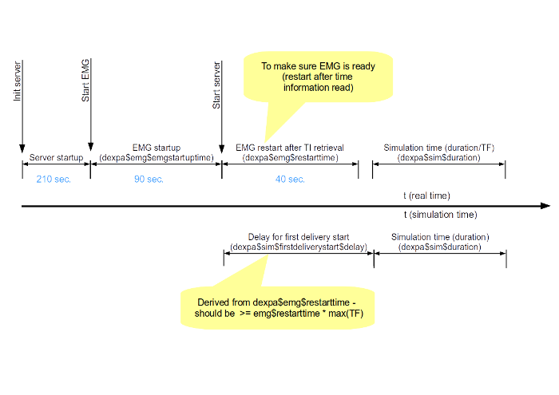

For instructions to run a simulation see Run.